# Homework 09

The kernel-tuning question moved here from Homework 08. A solution for Question 1 will be available after Monday, October 26, 2026. No solution will be provided for Question 2.

## Question 1: Choosing an SVM kernel

Use `saheart.csv` from the combined ZIP. As in Homework 7, predict `chd` using the same nine predictors, coding `famhist` as 1 for `Absent` and 2 for `Present`.

Compare SVMs with a linear kernel, polynomial kernels of degrees 2 (quadratic), 3, and 4, and a radial basis kernel. Choose **no more than 20 candidate settings in total** across these kernels. Vary the cost $C$ for each kernel and the radial scale $\gamma$ for the radial kernel. State any other kernel settings you hold fixed.

Divide the observations into five folds yourself and use the same folds for all candidates. Standardize predictors using only the fitting observations in each fold. Report the candidate settings and their mean cross-validation misclassification rates. Which kernel and settings do you prefer? Give a brief justification.

### Analysis

I compare 18 settings: three cost values for each of the linear and degree-2, degree-3, and degree-4 polynomial kernels, plus six radial-kernel combinations. For polynomial kernels, I hold `gamma` at $1/9$ and `coef0` at 0. For the radial kernel, I consider `gamma` values $1/9$ and $1/3$. These settings use the same cost candidates, $C \in \{0.1, 1, 10\}$.

The folds are stratified by `chd` and assigned once, so all candidate settings use identical folds. Within each fold, I compute predictor means and standard deviations from the fitting observations and apply those values to both the fitting and validation observations.

```r
library(e1071)

heart <- read.csv("data/saheart.csv")
heart$famhist <- ifelse(heart$famhist == "Absent", 1, 2)

predictor_names <- setdiff(names(heart), "chd")
x <- as.matrix(heart[, predictor_names])
y <- factor(heart$chd, levels = c(0, 1))

stopifnot(ncol(x) == 9, !anyNA(x), !anyNA(y))

set.seed(2026)
fold_id <- integer(nrow(heart))
for (class_label in levels(y)) {
  class_rows <- sample(which(y == class_label))
  fold_id[class_rows] <- rep(seq_len(5), length.out = length(class_rows))
}

cost_values <- c(0.1, 1, 10)
linear_candidates <- data.frame(
  kernel = "linear",
  degree = NA_integer_,
  cost = cost_values,
  gamma = NA_real_,
  coef0 = NA_real_
)
polynomial_candidates <- do.call(
  rbind,
  lapply(2:4, function(degree_value) {
    data.frame(
      kernel = "polynomial",
      degree = degree_value,
      cost = cost_values,
      gamma = 1 / ncol(x),
      coef0 = 0
    )
  })
)
radial_candidates <- expand.grid(
  cost = cost_values,
  gamma = c(1 / 9, 1 / 3)
)
radial_candidates$kernel <- "radial"
radial_candidates$degree <- NA_integer_
radial_candidates$coef0 <- NA_real_

candidate_grid <- rbind(
  linear_candidates,
  polynomial_candidates,
  radial_candidates[, names(linear_candidates)]
)
candidate_grid$family <- ifelse(
  candidate_grid$kernel == "polynomial",
  paste("Poly", candidate_grid$degree),
  ifelse(candidate_grid$kernel == "radial", "Radial", "Linear")
)
stopifnot(nrow(candidate_grid) <= 20)

fold_errors <- matrix(
  NA_real_,
  nrow = nrow(candidate_grid),
  ncol = 5
)

for (fold in seq_len(5)) {
  train_rows <- which(fold_id != fold)
  validation_rows <- which(fold_id == fold)

  train_x <- x[train_rows, , drop = FALSE]
  validation_x <- x[validation_rows, , drop = FALSE]
  predictor_means <- colMeans(train_x)
  predictor_sds <- apply(train_x, 2, sd)
  if (any(!is.finite(predictor_sds)) || any(predictor_sds == 0)) {
    stop("A fitting fold has a predictor with zero or invalid standard deviation.")
  }

  train_x <- scale(train_x, center = predictor_means, scale = predictor_sds)
  validation_x <- scale(
    validation_x,
    center = predictor_means,
    scale = predictor_sds
  )

  for (candidate in seq_len(nrow(candidate_grid))) {
    setting <- candidate_grid[candidate, ]
    fit <- svm(
      x = train_x,
      y = y[train_rows],
      type = "C-classification",
      kernel = setting$kernel,
      cost = setting$cost,
      degree = if (is.na(setting$degree)) 3 else setting$degree,
      gamma = if (is.na(setting$gamma)) 1 / ncol(x) else setting$gamma,
      coef0 = if (is.na(setting$coef0)) 0 else setting$coef0,
      scale = FALSE
    )
    prediction <- predict(fit, newdata = validation_x)
    fold_errors[candidate, fold] <- mean(prediction != y[validation_rows])
  }
}

candidate_grid$mean_cv_error <- rowMeans(fold_errors)
candidate_grid$sd_cv_error <- apply(fold_errors, 1, sd)
cv_results <- candidate_grid[
  order(candidate_grid$mean_cv_error, candidate_grid$kernel,
        candidate_grid$degree, candidate_grid$cost, candidate_grid$gamma),
]
cv_results$mean_cv_error <- sprintf("%.2f%%", 100 * cv_results$mean_cv_error)
cv_results$sd_cv_error <- sprintf("%.2f%%", 100 * cv_results$sd_cv_error)

result_table <- cv_results[, c("kernel", "degree", "cost", "gamma",
                               "mean_cv_error", "sd_cv_error")]
result_table$degree <- ifelse(is.na(result_table$degree), "-", result_table$degree)
result_table$gamma <- ifelse(
  is.na(result_table$gamma),
  "-",
  sprintf("%.3f", result_table$gamma)
)
rownames(result_table) <- NULL

knitr::kable(
  result_table,
  col.names = c("Kernel", "Polynomial degree", "C", "Gamma",
                "Mean CV error", "SD across folds"),
  caption = "Five-fold cross-validation results for all 18 candidate settings."
)
```

Five-fold cross-validation results for all 18 candidate settings.

| Kernel | Polynomial degree | C | Gamma | Mean CV error | SD across folds |
| --- | --- | --- | --- | --- | --- |
| linear | - | 1.0 | - | 27.73% | 8.00% |
| linear | - | 10.0 | - | 28.16% | 7.71% |
| linear | - | 0.1 | - | 28.37% | 7.49% |
| polynomial | 3 | 1.0 | 0.111 | 28.80% | 4.69% |
| radial | - | 1.0 | 0.111 | 29.24% | 6.85% |
| radial | - | 1.0 | 0.333 | 32.05% | 5.54% |
| radial | - | 10.0 | 0.111 | 32.26% | 3.63% |
| polynomial | 2 | 10.0 | 0.111 | 32.27% | 4.72% |
| polynomial | 4 | 1.0 | 0.111 | 32.90% | 1.45% |
| polynomial | 3 | 0.1 | 0.111 | 32.90% | 1.06% |
| polynomial | 3 | 10.0 | 0.111 | 32.91% | 2.15% |
| polynomial | 4 | 10.0 | 0.111 | 33.12% | 3.16% |
| polynomial | 2 | 1.0 | 0.111 | 33.34% | 1.77% |
| polynomial | 2 | 0.1 | 0.111 | 33.99% | 0.74% |
| polynomial | 4 | 0.1 | 0.111 | 33.99% | 1.06% |
| radial | - | 0.1 | 0.111 | 34.42% | 0.44% |
| radial | - | 0.1 | 0.333 | 34.63% | 0.20% |
| radial | - | 10.0 | 0.333 | 39.41% | 6.31% |

```r
best_index <- which.min(candidate_grid$mean_cv_error)
best_setting <- candidate_grid[best_index, ]
best_error <- candidate_grid$mean_cv_error[best_index]
runner_up_error <- sort(candidate_grid$mean_cv_error)[2]
best_kernel <- if (best_setting$kernel == "polynomial") {
  paste("degree", best_setting$degree, "polynomial")
} else {
  best_setting$kernel
}
best_gamma <- if (is.na(best_setting$gamma)) {
  "not applicable"
} else {
  format(best_setting$gamma, digits = 3)
}
best_description <- sprintf(
  "%s kernel (C = %g, gamma = %s)",
  best_kernel, best_setting$cost, best_gamma
)

family_indices <- split(seq_len(nrow(candidate_grid)), candidate_grid$family)
family_best_indices <- vapply(
  family_indices,
  function(indices) indices[which.min(candidate_grid$mean_cv_error[indices])],
  integer(1)
)
family_best <- candidate_grid[family_best_indices, ]
family_best$sd_cv_error <- apply(
  fold_errors[family_best_indices, , drop = FALSE],
  1,
  sd
)
family_order <- match(
  family_best$family,
  c("Linear", "Poly 2", "Poly 3", "Poly 4", "Radial")
)
family_best <- family_best[order(family_order), ]

selected_oof <- factor(rep(NA_character_, nrow(heart)), levels = levels(y))
for (fold in seq_len(5)) {
  train_rows <- which(fold_id != fold)
  validation_rows <- which(fold_id == fold)
  train_x <- x[train_rows, , drop = FALSE]
  validation_x <- x[validation_rows, , drop = FALSE]
  predictor_means <- colMeans(train_x)
  predictor_sds <- apply(train_x, 2, sd)
  train_x <- scale(train_x, center = predictor_means, scale = predictor_sds)
  validation_x <- scale(
    validation_x,
    center = predictor_means,
    scale = predictor_sds
  )
  fit <- svm(
    x = train_x,
    y = y[train_rows],
    type = "C-classification",
    kernel = best_setting$kernel,
    cost = best_setting$cost,
    degree = if (is.na(best_setting$degree)) 3 else best_setting$degree,
    gamma = if (is.na(best_setting$gamma)) 1 / ncol(x) else best_setting$gamma,
    coef0 = if (is.na(best_setting$coef0)) 0 else best_setting$coef0,
    scale = FALSE
  )
  selected_oof[validation_rows] <- predict(fit, newdata = validation_x)
}
selected_confusion <- table(
  Observed = factor(y, levels = c("0", "1")),
  Predicted = factor(selected_oof, levels = c("0", "1"))
)
selected_sensitivity <- selected_confusion["1", "1"] /
  sum(selected_confusion["1", ])
selected_specificity <- selected_confusion["0", "0"] /
  sum(selected_confusion["0", ])
class_counts <- table(y)
positive_rate <- as.numeric(class_counts["1"] / sum(class_counts))
baseline_error <- positive_rate

report_table <- data.frame(
  Kernel = family_best$family,
  `Best settings` = vapply(seq_len(nrow(family_best)), function(i) {
    setting <- family_best[i, ]
    gamma_text <- if (is.na(setting$gamma)) "" else
      paste0(", gamma=", format(setting$gamma, digits = 3))
    degree_text <- if (is.na(setting$degree)) "" else
      paste0(", degree=", setting$degree)
    paste0("C=", setting$cost, degree_text, gamma_text)
  }, character(1)),
  `Mean CV error (SD)` = sprintf(
    "%.2f%% (%.2f)",
    100 * family_best$mean_cv_error,
    100 * family_best$sd_cv_error
  ),
  Selected = ifelse(
    family_best$family == candidate_grid$family[best_index],
    "Yes",
    ""
  ),
  check.names = FALSE
)
```

I prefer the linear kernel (C = 1, gamma = not applicable) setting because it has the lowest mean five-fold cross-validation misclassification rate (27.73%) among the candidates considered. The next-lowest rate is 28.16%, so the difference is only 0.43 percentage points; I would not treat this small gap as strong evidence that the best setting is substantially better. The table reports the mean of the five fold-specific rates; the standard deviation gives a sense of how much the rate varies across folds. This comparison uses the same folds and fold-specific standardization for every candidate, so the validation rates are comparable. The selected setting is preferred among this candidate grid; it is not a claim that its error rate is the best possible for every future sample.

## Question 2: Write and use a short SVM analysis skill

In Homework 8, you reviewed another student’s skill. Review the comments and suggestions you received on your own Homework 7 skill. Use what you learned from both sides of the peer review to write a new, shorter skill for SVM model fitting.

**Instructor clarification (October 25, 2026):** AI tools may be used to help develop and write the SVM analysis skill. Create a `SKILL.md` with a short name and description in YAML frontmatter. The instruction body after the closing `---` of the frontmatter must be **no more than 50 lines**, including blank lines. Keep the skill independent of any particular dataset, variable names, or observed results, and load it only when you explicitly invoke it.

Your skill should direct the agent to:

1. judge whether the data are suitable for an SVM analysis;
2. choose which kernels to consider and explain why;
3. identify tuning parameters and a method for tuning them;
4. choose an evaluation method that supports selecting a final model;
5. require a compact figure and table that justify the choices;
6. interpret the fit and report the key numerical results; and
7. prioritize the evidence needed to justify the final model in **no more than one printed page at 11-point font**.

**Apply the skill.** Explicitly invoke your skill to analyze `saheart.csv`, using the same response, nine predictors, and `famhist` coding as in Question 1. Provide these data details when invoking the skill, not in the skill itself. Let the skill guide the analysis, then check the resulting report and calculations.

**Submit the results.** Include the one-page, 11-point analysis report in your Homework 09 submission and append the complete contents of your `SKILL.md` afterward. The appended skill is outside the one-page limit.

## SVM analysis report

**Skill invocation:** Apply `homework/week-09/SKILL.md` to `data/saheart.csv`; response `chd`; predictors `sbp`, `tobacco`, `ldl`, `adiposity`, `famhist`, `typea`, `obesity`, `alcohol`, and `age`; code `famhist` as 1 for Absent and 2 for Present.

The dataset has 462 observations and nine numeric predictors, with 0 missing values. `chd=1` accounts for 34.6% of observations, so I use stratified folds and report class-sensitive results alongside overall error. I compare 18 linear, polynomial, and radial SVM settings using five-fold cross-validation (seed 2026); scaling is estimated on each training fold only. Polynomial kernels use `gamma=1/9`, `coef0=0`, and degrees 2–4. Radial kernels use `gamma` 1/9 or 1/3. All kernels use `C` 0.1, 1, or 10.

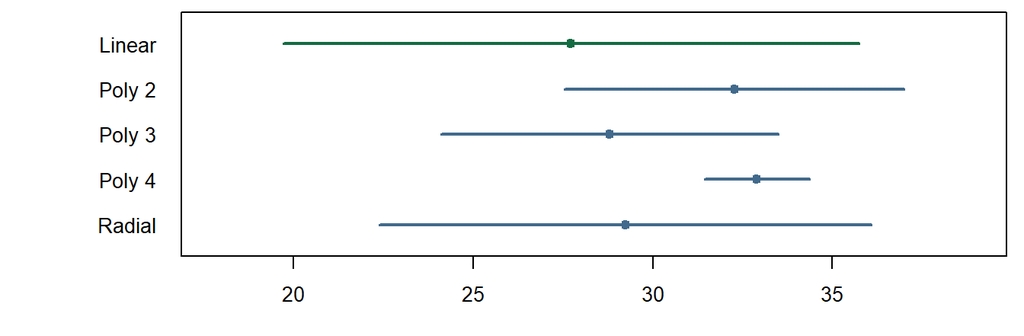

Best five-fold CV error by kernel family; bars show plus or minus one fold SD.

Best candidate in each kernel family; SD is across five fold errors.

| Kernel | Best candidate settings | Mean CV error (SD, pp) | Selected |
| --- | --- | --- | --- |
| Linear | C=1 | 27.73% (8.00) | Yes |
| Poly 2 | C=10, degree=2, gamma=0.111 | 32.27% (4.72) |  |
| Poly 3 | C=1, degree=3, gamma=0.111 | 28.80% (4.69) |  |
| Poly 4 | C=1, degree=4, gamma=0.111 | 32.90% (1.45) |  |
| Radial | C=1, gamma=0.111 | 29.24% (6.85) |  |

The selected model is the linear kernel (C = 1, gamma = not applicable) (mean CV error 27.73%). Its fold-held-out sensitivity is 51.9% and specificity is 83.1%; these estimates reuse the tuning folds, so selecting the winner may make them optimistic. Always predicting `chd=0` would err on 34.6% of cases, illustrating why overall error alone is incomplete. The next-best candidate is only 0.43 percentage points higher in CV error, so the evidence does not show a meaningful advantage for a more complex model. Five-fold CV summarizes this dataset and candidate grid, not guaranteed future performance.

## SVM analysis skill

```markdown
---
name: svm-analysis
description: Analyze classification data with SVMs, tune kernels, and report justified results.
---

# SVM analysis

Use these instructions only when the user explicitly invokes this skill.

1. Check the response, predictors, sample size, missingness, class balance, and whether predictors can be represented numerically. Flag limitations before fitting.
2. Select a small, justified set of linear, polynomial, and/or radial kernels. Explain why each is plausible; do not fit every kernel by default.
3. State the candidate values for cost `C` and kernel-specific parameters such as `gamma`, polynomial degree, and offset. Keep the search feasible and reproducible.
4. Choose cross-validation suitable for the sample size and class balance. Use identical folds across candidates; fit imputation, scaling, or other preprocessing using only each training fold.
5. Choose the model using a stated validation metric. For imbalanced classes, report class-sensitive measures as well as overall error. Use nested validation or an independent test set when available for less biased final performance estimates.
6. Fit selected candidates, check convergence and predictions, and record seed, fold construction, settings, and numerical results. Do not describe validation performance as guaranteed future performance.
7. Include one compact figure comparing candidate performance and one compact table of settings and relevant metrics. Label units and make the selected setting clear.
8. Interpret the selected fit, compare it with a simple baseline, state meaningful uncertainty or limitations, and distinguish predictive association from causation.
9. Prioritize only evidence needed to justify the final model. Keep the analysis report to no more than one printed page at 11-point font.
```